# Jupyter et ses notebook

Jupyter est une application web (c'est-à-dire qu'elle s'execute dans un navigateur), mais on peut la lancer en local (elle lance alors un navigateur automatiquement).

Dans Jupyter on manipule en général ce que l'on appelle des Notebooks. Un notebook (dont vous voyez un exemplaire non interactif en ce moment) est une feuille permettant de mêler texte et programmation via des cellules de code:

```python
for(int i=0;i<16;i++){
    printf("%d ",i);
}
```

```
0 1 2 3 4 5 6 7 8 9 10 11 12 13 14 15
```

On peut mélanger des codes en différents langages dans la même feuille et afficher directement les graphiques:

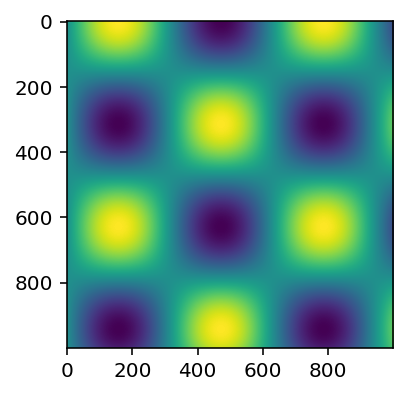

```python
import numpy as np
import matplotlib.pyplot as plt
x = np.linspace(0, 10, 1000);matrix = np.sin(x) * np.cos(x[:, np.newaxis])
plt.figure(figsize=(3,3));plt.imshow(matrix);plt.show()
```

On peut enfin écrire des formules mathématiques (en Latex): $\displaystyle\int_{-\infty}^{+\infty}e^{-x^2}=\sqrt{\pi}$

Pour accéder à l'application Jupyter on peut soit la lancer en local (à partir de notre ordinateur) soit se connecter à un serveur proposant cette application. Certains serveurs sont publics, parmi lesquels [MyBinder](https://mybinder.org/) ou Cocalc. Il est également possible de monter soi-même un serveur à disposition d'autres utilisateurs en utilisant des outils comme [JupyterHub](https://jupyter.org/hub) ou [Cocalc-Docker](https://github.com/sagemathinc/cocalc-docker).

# Intérêt Pédagogique de Jupyter et de ses Notebooks

J'y vois principalement les intérêts suivants:

- Proposer l'apprentissage de plusieurs langages de programmation dans un seul et même environnement, sans avoir à gérer plusieurs installations: on minimise le nombre d'installations nécessaires.
- En allant plus loin, si l'on met en place un serveur il n'y a même plus d'installation nécessaire.
- Toujours si l'on met en place un serveur, il est aisé de partager des documents avec les étudiants. Ils pourront également collaborer sur des espaces partagés. Certains outils de déploiement (comme CoCalc-Docker) permettent même de gérer l'édition simultanée.
- Les notebooks permettent d'intégrer l'énoncé de TP avec le compte-rendu de TP: les étudiants peuvent répondre directement sur l'énoncé de TP dans les cellules de code que l'on prévoit à cet effet. Ils executent leur code sur le compte-rendu de TP.
- Au niveau des mathématiques on peut mêler calcul numérique (avec par exemple SciPy ou Scilab) et calcul formel (avec SageMath ou SymPy).

Gabriel Soranzo

Enseignant à l'IUT GEII de l'UPEC

gabriel.soranzo@u-pec.fr